# Data Science Project - Final 3&4Q

Madhu Babu Avula

2024-12-08

```r
library(dplyr)
library(tidyverse)
deaths <- read.csv("Deaths_in_122_U.S._cities_-_1962-2016._122_Cities_Mortality_Reporting_System_20241019.csv")
stations <- read.csv("Station_weather_data.csv")
```

### Analysis of Mortality by Age Group

- **Objective**: Analyze how different age groups are affected by mortality and identify the most at-risk population.

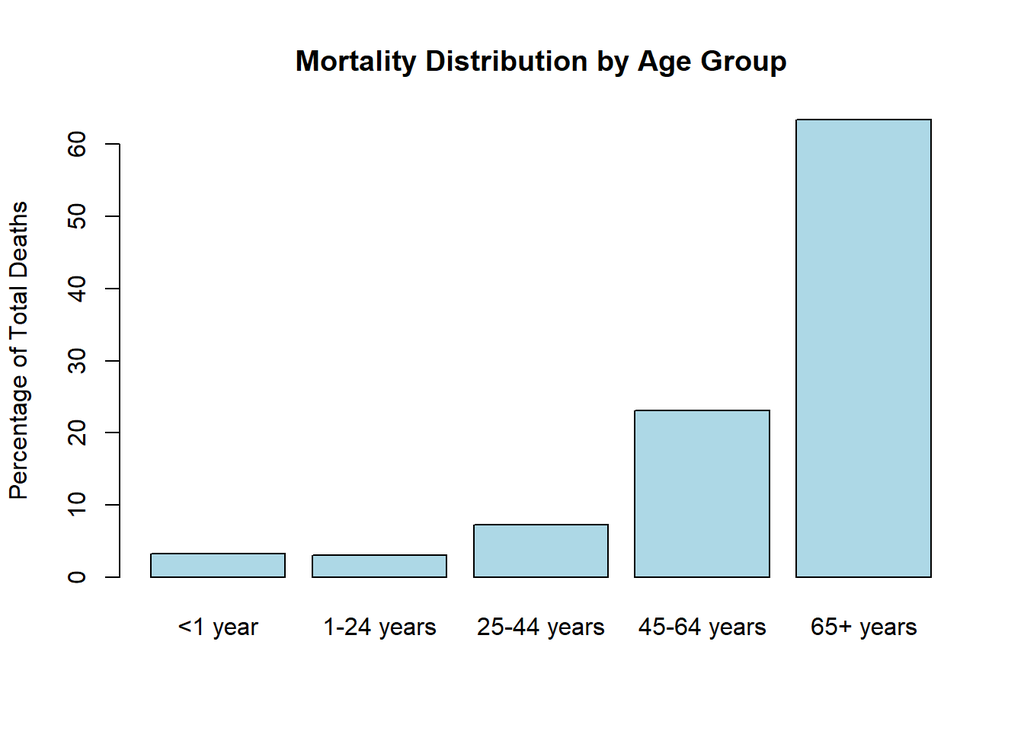

```r
# Summarize total deaths by age group
age_groups <- c("X.1.year..all.cause.deaths.", "X1.24.years..all.cause.deaths.",
                "X25.44.years", "X45.64.years..all.cause.deaths.", "X65..years..all.cause.deaths.")
total_deaths <- colSums(deaths[, age_groups], na.rm = TRUE)

# Calculate percentages
percent_deaths <- total_deaths / sum(total_deaths) * 100

# Plot the data
barplot(percent_deaths, names.arg = c("<1 year", "1-24 years", "25-44 years", "45-64 years", "65+ years"),
        main = "Mortality Distribution by Age Group", ylab = "Percentage of Total Deaths", col = "lightblue")
```

- **Key Findings**:
  - The **65+ years** age group accounts for the highest percentage of total deaths, contributing over 60% of mortality.
  - The **45–64 years** age group is the second most affected, with a significant but smaller share.
  - Younger age groups, including **<1 year**, **1–24 years**, and **25–44 years**, have considerably lower mortality percentages.
- **Conclusion**:
  - Older adults (**65+ years**) are the most vulnerable group, indicating a need for targeted health interventions.
  - The **45–64 years** group also requires attention, but with lower priority compared to seniors.

## Analysis of Weather Events Impacting Mortality

### Objective

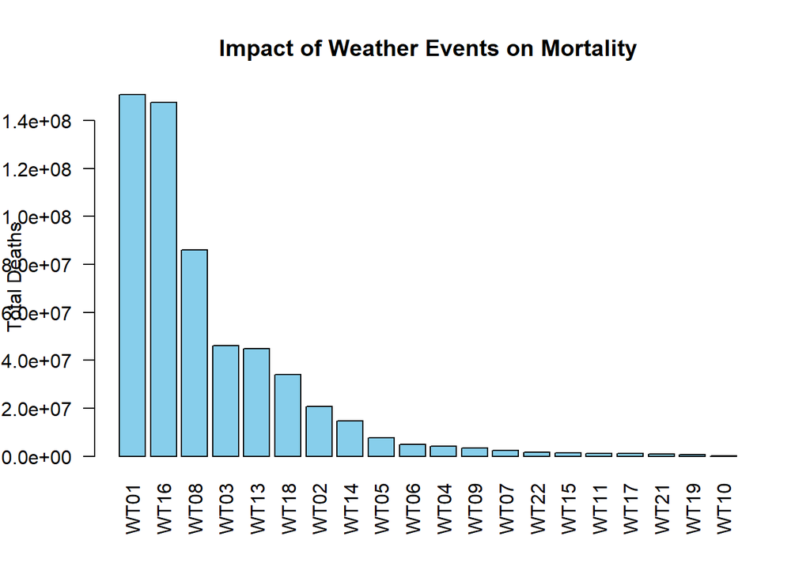

```r
# Filter existing weather columns
existing_weather_columns <- intersect(paste0("WT", sprintf("%02d", 1:22)), colnames(stations))

# Merge datasets by date
stations$DATE <- as.Date(stations$DATE, "%m/%d/%Y")
deaths$Week.Ending.Date <- as.Date(deaths$Week.Ending.Date, "%m/%d/%Y")
merged_data <- merge(stations, deaths, by.x = "DATE", by.y = "Week.Ending.Date")

# Calculate mortality for each weather event

weather_impact <- merged_data %>%
  select(all_of(existing_weather_columns), All.Deaths) %>%
  pivot_longer(cols = starts_with("WT"), names_to = "Weather_Event", values_to = "Occurred") %>%
  filter(Occurred == 1) %>%
  group_by(Weather_Event) %>%
  summarize(Total_Deaths = sum(All.Deaths, na.rm = TRUE)) %>%
  arrange(desc(Total_Deaths))

# Visualize
barplot(weather_impact$Total_Deaths,
        names.arg = weather_impact$Weather_Event,
        main = "Impact of Weather Events on Mortality",
        ylab = "Total Deaths",
        las = 2,
        col = "skyblue")
```

### Key Findings

- **WT01 (Fog, ice fog, or freezing fog)** and **WT16 (Rain, including freezing rain)** have the highest associated mortality, exceeding 1.4 × 10^8 deaths each.
- Other weather events with notable impacts include:
  - **WT08 (Smoke or haze)**
  - **WT03 (Thunder)**
  - **WT13 (Mist)**
  - **WT18 (Snow, snow pellets, or ice crystals)**
- Events like **WT10 (Tornado, waterspout, or funnel cloud)** and **WT22 (Ice fog)** have minimal impacts on mortality.

### Conclusion

- **Fog and rain-related events** pose the greatest risks to mortality, likely due to reduced visibility, accidents, or secondary health impacts.
- **Smoke/haze and snow events** also contribute significantly, highlighting their environmental and safety hazards.